# Association rules

Movie recommender systems

Yasmin Sarcheshmehpour 94109827

2018-07-13 21:24:39

> با استفاده از داده نظرهای فیلم به سوالات زیر پاسخ دهید.

۱. آماره های زیر را بیابید. الف. محبوب ترین فیلم کدام است؟ ب. بیشترین نظرات درباره چه فیلمی داده شده است؟ پ. منفورترین فیلم کدام است؟ ت. تعداد فیلم های ساخته شده در هر سال ث. در هر سالی مردم به چه ژانری علاقه مند بوده اند.

```r
rating_data %>% group_by(movie_id) %>% summarise(mean_rating=sum(rating)/n(), count=n()) %>%
  merge(movie_data) %>% select(movie_id, movie_title, mean_rating, count)-> normalize_data


normalize_data %>%  filter(count>=100) %>% arrange(-mean_rating, -count) %>% head()
```

[output not shown]

```r
normalize_data %>% arrange(-count) %>% head()
```

```
##   movie_id                      movie_title mean_rating count
## 1      296              Pulp Fiction (1994)    4.157426 34864
## 2      593 Silence of the Lambs, The (1991)    4.204200 33668
## 3      480             Jurassic Park (1993)    3.661564 32631
## 4      318 Shawshank Redemption, The (1994)    4.457238 31126
## 5      110                Braveheart (1995)    4.082390 29154
## 6      457             Fugitive, The (1993)    4.006925 28951
```

```r
normalize_data %>% filter(count>=100) %>% arrange(mean_rating, -count) %>% head()
```

```
##   movie_id                                         movie_title mean_rating
## 1     6483                         From Justin to Kelly (2003)   0.9236111
## 2     6371                               Pokémon Heroes (2003)   1.0096154
## 3     5672 Pokemon 4 Ever (a.k.a. Pokémon 4: The Movie) (2002)   1.1759657
## 4     6872                       House of the Dead, The (2003)   1.3225108
## 5     1990          Prom Night IV: Deliver Us From Evil (1992)   1.3564356
## 6     5647                        Ernest Goes to Africa (1997)   1.3880597
##   count
## 1   216
## 2   156
## 3   233
## 4   231
## 5   101
## 6   134
```

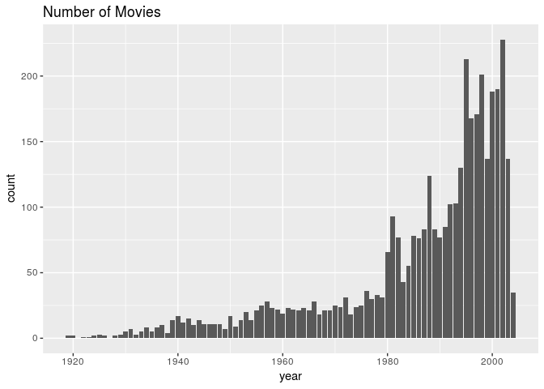

```r
ggplot(movies,aes(x=year)) + geom_bar() + ggtitle("Number of Movies")
```

```r
genre_data %>% group_by(year) %>% filter(mean_rating==max(mean_rating)) %>%  select(year, genre, mean_rating)
```

```
## # A tibble: 95 x 3
## # Groups:   year [84]
##     year genre           mean_rating
##    <int> <fct>                 <dbl>
##  1  1919 genre_Adventure        2.92
##  2  1919 genre_Drama            2.92
##  3  1920 genre_Romance          3.47
##  4  1920 genre_Drama            3.47
##  5  1922 genre_Drama            3
##  6  1923 genre_Drama            3.53
##  7  1924 genre_Comedy           3.97
##  8  1925 genre_Adventure        4.12
##  9  1925 genre_Romance          4.12
## 10  1926 genre_Comedy           3.68
## # ... with 85 more rows
```

۲. ژانر فیلم ها را استخراج نمایید. سپس آماره های زیر را استخراج نمایید. الف. نمودار ستونی تعداد فیلم های هر ژانر ب. نمودار همبستگی ژانرها پ. متوسط امتیاز به هر ژانر ت. دوران طلایی فیلم سازی

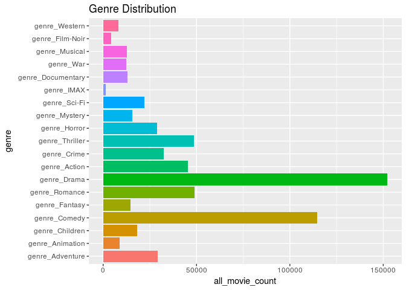

```r
genre_data %>% group_by(genre) %>% mutate(all_movie_count=sum(movie_count))  %>%
  ggplot(aes(x=genre,y=all_movie_count,fill=genre)) +
    geom_bar(stat = "identity") +
    coord_flip() +
    ggtitle("Genre Distribution") +
    theme(legend.position = "none")
```

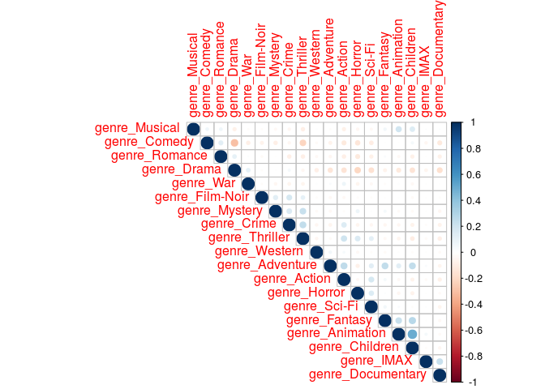

```r
movies[, 6:24] -> cor_data
cor_data %>% cor() %>% round(2) -> cor_mat
corrplot(cor_mat, type="upper", order="hclust", sig.level = 0.01, insig ="blank")
```

```r
genre_data %>% group_by(genre) %>% mutate(year_mean_rating=mean_rating) %>% summarise(mean_rating=sum(year_mean_rating*user_count)/sum(user_count)) %>%
  hchart("column",hcaes(x = genre, y = mean_rating))
```

[interactive chart not shown]

```r
rating_data %>% group_by(year) %>% summarise(mean_rating=mean(rating), var=var(rating), count=n()) %>% mutate(score=mean_rating/var) %>% arrange(-score) %>% head(5)
```

```
## # A tibble: 5 x 5
##    year mean_rating   var count score
##   <dbl>       <dbl> <dbl> <int> <dbl>
## 1  1934        4.09 0.671  5806  6.09
## 2  1946        4.12 0.692  8836  5.96
## 3  1951        4.03 0.677  7266  5.96
## 4  1948        4.06 0.683  8088  5.95
## 5  1936        3.97 0.674  1656  5.90
```

۳. نمودار ابر لغات را بر حسب کلمات عنوان فیلم ها رسم نمایید.

```r
lower = function(strings) {
  ans = c()
  for (string in strings){
    if (startsWith(string, '(') & endsWith(string, ')')) next
    normalize_str = str_replace_all(string,"[^a-zA-Z1-9\\s]", "")
    ans = c(ans, str_to_lower(normalize_str))
  }
  return(ans)
}

split_str_by_space = function(str) {
  return (unlist(strsplit(str,split=' ')))
}


words = unlist(lapply(as.character(movie_data$movie_title), split_str_by_space)) %>% lower()

head(words)
```

```
## [1] "toy"      "story"    "jumanji"  "grumpier" "old"      "men"
```

```r
words_data = words %>%
 unlist() %>%
 table() %>%
 as.data.frame(stringsAsFactors = F)
 colnames(words_data) = c("word","count")

words_data %>% arrange(-count) -> words_data

words_data = words_data %>%
 filter(!str_to_lower(word) %in% stop_words$word) %>%
 filter(length(word) > 1) %>%
 arrange(desc(count)) %>%
 mutate(lower = str_to_lower(word))


wordcloud2(head(words_data, 200), size = 1)
```

[interactive chart not shown]

۴. با استفاده از قوانین همبستگی یک توصیه گر برای فیلم ها بسازید. شبیه ترین فیلم ها به لیست زیر را پیدا کنید.

```r
rating_data = na.omit(rating_data)
user_item_matrix <- as(split(rating_data[,'movie_title'], rating_data[, 'user_id']), "transactions")

rule_param = list(
    supp = 0.001,
    conf = 0.7,
    maxlen=2
)

assoc_rules = apriori(user_item_matrix, parameter = rule_param)
```

[output not shown]

```
##  done [1.00s].
## writing ... [43220 rule(s)] done [0.03s].
## creating S4 object  ... done [0.03s].
```

```r
cast_away_rules = subset(assoc_rules, subset=(lhs %in% c('Cast Away (2000)') | rhs %in% c('Cast Away (2000)')))
inspect(sort(cast_away_rules, by = "lift")[1:10])
```

[output not shown]

```r
Castle_rules = subset(assoc_rules, subset=(lhs %in% c('Castle in the Sky (Tenkû no shiro Rapyuta) (1986)') | rhs %in% c('Castle in the Sky (Tenkû no shiro Rapyuta) (1986)')))
inspect(sort(Castle_rules, by = "lift")[1:10])
```

[output not shown]

۵. تمرین سخت: در گیت هاب برای خود اکانت درست کنید. همه تمرین های خود را آنجا بارگذاری کنید! و لینک آن را ارسال نمایید.

https://gitlab.com/sahelyiyi/DataAnalysis

۶. پنج انتقاد از درس و نحوه تدریس را بیان کنید.

بهتر بود نمرات قبل از ترمیم داده میشدند.

۷. پنج پیشنهاد برای بهتر شدن درس بیان کنید.

۸. سه موضوع آماری جدید برای جایگزینی در سرفصل ها پیشنهاد دهید.

۹. سه داده جالب برای کار در کلاس پیشنهاد دهید.

۱۰. چهار نکته مهمی که در کلاس یاد گرفتید را بیان کنید.

در کل شهود خیلی خوبی نسبت به کار تحلیل داده به دست آوردم که خیلی برام ارزش داره و ترسی که نسبت به کار با دیتا داشتم از بین رفت.